# TEGEGNE01705625_CW1

## Outline

- Task 1: Regression
  - 1.1 Linear regression
  - 1.2 Ridge regression
  - 1.3 Relaxation of Lasso regression
- Task 2: Classification
  - 2.1 kNN classifier
  - 2.2 Random forest
  - 2.3 Support vector machine (SVM)

# Task 1: Regression ^

In this section we will be working with a chemistry data set based on molecular descriptors for different chemicals. There are 10 covariates or predictors affect the toxicity level "LC50", which will be considered the output variable. As the data is continuous will be perform regression and investigating how effective linear, ridge and lasso regression are.

## 1.1 ^ Linear Regression

We fit a linear model of Y against X, where Y is a vector that holds the output "LC50" and X is a matrix containing the other 10 covariates as columns and another columns of 1s; $$ Y = X \beta + \epsilon $$ we assume that the residuals are normally distributed and independant. $$ \epsilon_i \stackrel{i.i.d}{\sim} N(0, \sigma^2) \quad i = 1,.., N $$

```python
import csv
import numpy as np
import pandas as pd
import matplotlib.pyplot as plt

chem_sample = pd.read_csv("chemistry_samples.csv")
chem_test = pd.read_csv("chemistry_test.csv")

#Set train and test data, and convert to arrays
x_train = pd.DataFrame.to_numpy(chem_sample.iloc[:,0:10])
Y_train = pd.DataFrame.to_numpy(chem_sample["LC50"])

x_test = pd.DataFrame.to_numpy(chem_test.iloc[:,0:10])
Y_test = pd.DataFrame.to_numpy(chem_test["LC50"])

chem_sample.head() # first 10 columns are predictors, last is target variable/output
```

|  | CIC0 | SM1_Dz(Z) | GATS1i | NdsCH | NdssC | MLOGP | FV1 | VFV | FV2 | FV3 | LC50 |
| --- | --- | --- | --- | --- | --- | --- | --- | --- | --- | --- | --- |
| 0 | 3.661280 | 0.658363 | 1.602232 | 1.994272 | 0.836488 | 3.153623 | 15.893033 | -27.724370 | 0.059355 | 0.756698 | 5.506249 |
| 1 | 3.936362 | 1.154287 | 1.146997 | 0.904295 | 2.948308 | 5.141095 | 13.590177 | -31.821521 | -13.408855 | 1.161298 | 6.636791 |
| 2 | 0.964144 | 0.415485 | 1.481028 | 2.136585 | 0.043679 | -1.156783 | 15.989419 | -3.699312 | 2.561525 | 0.500115 | 1.563388 |
| 3 | 2.074617 | 1.417296 | 0.486216 | 0.000908 | -0.066980 | 2.610960 | 7.962046 | -16.374439 | 2.448975 | 1.481888 | 6.248432 |
| 4 | 1.448569 | 0.836892 | 1.951012 | 0.028318 | -0.039121 | 1.851095 | 22.285266 | -9.526361 | 2.870400 | 0.649234 | 3.676796 |

We find our maximum likelihood estimator $\hat{\boldsymbol \beta}_{ML}$ for $\boldsymbol\beta$ by maximising the log likelihood: $$ L(Y | X, \beta, \sigma^2)= -\frac{N}{2}log(2\pi \sigma^2) - \frac{1}{2 \sigma^2}(Y - X \beta)^T(Y- X \beta) $$ By taking the gradient of the log likelihood and setting it equal to 0, $$ \nabla_{\beta}L(Y | X, \beta) = -\frac{1}{2\sigma^2} (-2 X^T Y + 2(X^T X)\beta)$$ we obtain our maximum likelihood estimator. $$ \hat{\boldsymbol \beta}_{ML} = (X^T X)^{-1} X^T Y$$.

Note that the maximum likelihood estimator also minimises the loss function

$$ L(\beta) = \lVert Y- X\beta \rVert ^2 .$$

```python
def beta_ml(Y, x):
    """ Fit Y against x and output least squares estimator"""
    N, D = x.shape
    X = np.hstack((np.ones((N,1)), x)) #concatenate vector of 1s to create intercept term in beta
    return np.linalg.solve(X.T @ X, (X.T @ Y)) #solve normal equation

def MSEmin(Y, x, beta):
    N, D = x.shape
    X = np.hstack((np.ones((N,1)), x)) #concatenate vector of 1s to create intercept term in beta
    return np.mean((Y - X @ beta)**2)

beta = beta_ml(Y_train,x_train)
print("Maximum likelihood estimator parameters are:", beta, "\n MSE minimised at", round(MSEmin(Y_train, x_train,beta),5))
```

```
Maximum likelihood estimator parameters are: [ 2.61638041e+00  4.47138333e-02  1.25871884e+00 -3.80092765e-02
  3.63073448e-01  4.66534882e-03  3.90510052e-01 -7.46028629e-02
 -3.57069460e-02 -1.52588258e-02 -1.80315922e-03]
 MSE minimised at 0.18651
```

We now compute the coefficient of determination, $$ R^2 = 1 - \frac{\lVert Y- X \hat{\boldsymbol \beta} \rVert ^2}{\lVert Y- \bar{Y} \rVert ^2}$$ which is at most 1. The higher $R^2$ is, the more accurate our fitted model is, because it quantifies how much smaller the residual sum of squares is for our model compared to when one parameter is used,and the fitted value of y is set to the mean value of y from the sample data.

```python
def Rsquared(Y, x, beta):
    N, D = x.shape
    X = np.hstack((np.ones((N,1)), x))
    e = Y - X @ beta # residuals
    RSS = e.T @ e # residual sum of squares
    RSS_0 = np.sum((Y- np.mean(Y))**2) # residual sum of squares if beta contains only intercept
    R2 = 1- RSS/RSS_0
    return R2

print ("In-sample Coefficient of determination is:", round(Rsquared(Y_train, x_train , beta), 5))
print ("Out-of-sample Coefficient of determination is:", round(Rsquared(Y_test, x_test , beta), 5))
```

```
In-sample Coefficient of determination is: 0.87183
Out-of-sample Coefficient of determination is: 0.86429
```

Our coefficient of determinations differ by approximately 0.01 when we compare how the model performs with our original sample and the test data, which implies our model is just as good at predicting out of sample, compared to in sample. $R^2$. As both are above 0.85 which implies we can make predictions with high confidence. It is straightforward to show that the variance of $\hat{\beta}_{\text{MLE}}$ is $\sigma^2 (X^T X)^{-1}$, which can be very large if $X^T X$ has large values. In the next section we will explore shrinkage methods that attempt to reduce the variance of our estimator.

## 1.2 ^ Ridge Regression

We will now perform ridge regression on the data, where we now try to minimise a new loss function, $$ L_{ridge}(\beta) = \lVert Y- X\beta \rVert ^2 + \lambda \lVert \beta \rVert^2 .$$ where $\lambda > 0$ penalises the estimator if its norm is large. We first define the MSE (mean squared error) of $\hat{\beta}$, an estimator for $\beta$, which measures how accurate an estimator is $$ \text{MSE}(\hat{\beta}, \beta) = \text{E}^2(\hat{\beta} - \beta) + \text{Var}(\hat{\beta}).$$ This should not be confused with the (sample) MSE of the fitted values, $\lVert \hat{Y} - Y \rVert ^2/n$, which we will frequently refer to. Compared to the MLE (minimum likelihood estimator) the ridge estimator has a smaller variance but has a larger bias, the MLE is unbiased. The larger $\lambda$ is, the smaller the variance of the ridge estimator is and the larger its bias. If we can work with this trade-off, we can pick a $\lambda$ where our ridge estimator has a smaller mean squared error. The minimiser of the ridge loss function can be computed explicity: $$ \hat{\boldsymbol \beta}_{ridge} = (X^T X + \lambda I)^{-1} X^T Y $$

```python
def beta_ridge(Y,x,lamda):
    """ Fit linear model of Y against x and compute ridge regression estimator with penalty term lamda"""
    N, D = x.shape
    X = np.hstack((np.ones((N,1)), x))
    return np.linalg.solve(X.T @ X + lamda*np.identity(D+1), (X.T @ Y))
```

We now perform hyperparameter tuning to find the optimal penalty term $\lambda$ with T-fold Cross Validation. For now we ignore the test data (out of sample data) and use only the training data, and set T= 5. The algorithm is as follows:

1. Split training data S into T subsets : $S_1, .. S_5$
2. For every $i = 1,..,5$ , train the model on $\bar{S_i} = S \setminus S_i$ with ridge regression
3. Use fitted model to predict $S_i$ and compute the MSE against actual values of $S_i$
4. Compute the mean MSE over all folds
5. Repeat over range of $\lambda$ values, and observe where MSE is minimised

```python
#Shuffle rows of training and test data
p1 = np.random.permutation(len(Y_train))
x_train = x_train[p1]
Y_train = Y_train[p1]

p2 = np.random.permutation(len(Y_test))
x_test = x_test[p2]
Y_test = Y_test[p2]

#Split training data into 5 folds, where last fold has one more row than the other 5 folds
folds_indexes = np.split(np.arange(len(Y_train)), [822,1644,2466,3288])

def score(x_train, Y_train, x_test, Y_test, lamda):
    """ Perform ridge regression of Y_train against x_train with penalty term lamda
         , then fix ridge estimator and use it to train x_test and compute its mean
         squared error against Y_test"""

    #Fit Y_train against X_train
    betaridge = beta_ridge(Y_train,x_train,lamda)
    N, D = x_test.shape

    #Compute fitted Y values
    X = np.hstack((np.ones((N,1)), x_test))
    Y_pred = X @ betaridge

    #Output MSE
    return np.mean((Y_test - Y_pred)**2) # return MSE
```

First we have defined a score function to compute the mean squared error for ridge regression, which we now use to perform 5-fold cross-validation

```python
def cross_validation_score(x_train, Y_train, folds, lamda): #average MSE across T=5 folds
  """ Compute cross validation score across training data, performing ridge regression
  with penalty term lamda """
  scores = []
  for i in range(len(folds)):

    # Set fold S_k out of one of the 5 folds, and store its complement
    val_indexes = folds[i]
    train_indexes = list(set(range(Y_train.shape[0])) - set(val_indexes))

    x_train_i = x_train[train_indexes, :]
    Y_train_i = Y_train[train_indexes]

    x_val_i = x_train[val_indexes, :]
    Y_val_i = Y_train[val_indexes]


    #Compute MSE trained model against actual data
    score_i = score(x_train_i, Y_train_i, x_val_i, Y_val_i, lamda)
    scores.append(score_i)

  # Return the mean squared error over all 5 folds
  return sum(scores)/len(scores)
```

Compute the cross validation score for $\lambda = 0, 0.01,..,1$ and output the $\lambda$ that minimises the CV score.

```
MSE is minimised at 0.1876 and optimal lambda is 0.19 to 2 d.p
```

[figure not shown]

```python
#Plot CV score for lambda up to 1
lambda_range = np.arange(0, 1,0.01)
cvscores = [cross_validation_score(x_train, Y_train, folds_indexes,i) for i in lambda_range]

plt.plot(lambda_range, cvscores)
plt.ylabel('MSE')
plt.xlabel('lambda')
plt.title("MSE vs penalty term lambda")

# Report best lambda(to 2 d.p) and corresponding MSE
lambda_best = lambda_range[np.argmin(cvscores)]
MSE_min = min(cvscores)
print("MSE is minimised at", round(MSE_min,5), "and optimal lambda is", lambda_best,"to 2 d.p")
```

Now fix $\lambda$ and retrain on the entire training data, as well as the test data, to obtain the coefficient of determination.

```python
betaridge = beta_ridge(Y_train,x_train,lambda_best)
print ("In sample Coefficient of determination is:", round(Rsquared(Y_train, x_train , betaridge), 5))
print ("Out of sample Coefficient of determination is:", round(Rsquared(Y_test, x_test , betaridge), 5))
```

```
In sample Coefficient of determination is: 0.87183
Out of sample Coefficient of determination is: 0.8643
```

## 1.3 ^ Lasso Regression

We now will use Lasso regression, where we minimise the loss function $$ L_{lasso}(\beta) = \lVert Y- X\beta \rVert ^2 + \lambda \sum_{i=1}^p L_c(\beta_i) $$ $$ \text{where} \quad L_c(\beta_i) = \begin{cases} \frac{1}{2}\beta_i^2 & \text{if} |\beta_i| \leq c \\ c(|\beta_i| - \frac{1}{2}c) & \text{otherwise} \\ \end{cases} \quad p = \text{number of parameters}, c = 0.001$$

The penalty term is approximated with Huber functions $L_c$, which are smooth. We cannot find an analytical solution for the minimum of the Lasso loss function, so instead we will use gradient descent. $$ [\nabla_{\beta}L_{\text{lasso}}(\beta)]_i = [2(X^T X)\beta -2 X^T Y]_i + \lambda [\nabla_{\beta}L_c]_i$$ $$ \text{where} [\nabla_{\beta}L_c]_i = \begin{cases} -c & \text{if} \beta_i < -c \\ \beta_i & \text{if} c \leq \beta_i \leq c \\ c & \text{if} \beta_i > c \\ \end{cases}$$

In gradient descent, we first initalise $\beta_0$, and iteratively define $\beta_{k+1} = \beta_{k} - \eta_k \nabla_{\beta} L_{\text{lasso}}(\beta_k)$. The step size $\eta_k$ can be chosen appropiately to speed up convergence- in this case will we set it to be constant for convenience. Ideally, every time $\beta_k$ is updated, its distance from the global minimiser of the Lasso-Huber loss functions reduces- this may not be true if the step size isnt chosen appropiately or the loss function is non-convex.

We will use stochastic gradient descent, a type of gradient descent which instead samples from the data set and computes an approximation to the gradient- this is particularly helpful when working with large datasets. This can result in faster convergence, although it may not accurately reach the actual minimum like standard gradient descent does.

```python
def huber(beta, c=1e-3):
    """ Input beta and c, output value of Huber function"""
    return sum([0.5*i**2 if abs(i) <= c else c*(abs(i)-0.5*c) for i in beta])

def grad_huber(beta, c=1e-3):
    """ Input beta and c, output gradient of Huber function"""
    return np.array([i if abs(i) <= c else c*np.sign(i) for i in beta])
```

Now that we have defined the Huber function and its gradient, we can perform stochastic gradient descent, where we will print the cost and mean squared error every time the number of iterations doubles.

```python
c = 1e-3
def minimize_ls_huber(X, y, lambd, max_iterations=10000, stop_criterion=1e-5, batch_size = 16,
                       learning_rate=1e-4, print_outcome=False):
    # initialise zero weights
    beta = np.zeros(X.shape[1]+1).T
    nth = 0
    # initialise starting cost as infinity
    prev_cost = np.inf

    # stochastic gradient descent
    indices = np.arange(len(y))
    for iteration in np.arange(1, max_iterations):
        # shuffle to prevent repeating update cycles
        np.random.shuffle(indices)
        batch_idx = indices[:batch_size]
        X_b, y_b = X[batch_idx], y[batch_idx]
        for xi, yi in zip(X_b, y_b):

            n = len(xi)
            xi = np.concatenate((np.array([1]), xi))
            XX = np.outer(xi, xi)
            Xy = xi.T * yi

            ascent = 2*(XX @ beta - Xy) + lambd* grad_huber(beta, c)
            beta = beta - (learning_rate)*ascent

        # convergence check on 2^n'th iteration
        if iteration==2**nth or iteration==max_iterations-1:
            # compute cost
            n, p = X.shape
            X_ = np.hstack((np.ones((n,1)), X))
            mse = np.mean((y- X_ @ beta)**2)
            cost = mse*n + lambd * huber(beta)
            if print_outcome:
                print("Iteration is: {}, Cost is: {}, MSE is: {}".format(iteration, cost, mse))
            # stop criterion
            if abs(prev_cost - cost) < stop_criterion * prev_cost:
                return beta

            prev_cost = cost
            nth += 1

    return beta
```

```python
minimize_ls_huber(x_train, Y_train, lambd = 10, max_iterations=20000, learning_rate=1e-4,print_outcome = True)
```

```
Iteration is: 1, Cost is: 8387.370415365653, MSE is: 2.040225589838164
Iteration is: 2, Cost is: 7856.371018919616, MSE is: 1.9110601548982815
Iteration is: 4, Cost is: 7487.216881833604, MSE is: 1.8212633955967192
Iteration is: 8, Cost is: 7144.207305216037, MSE is: 1.7378262922176004
Iteration is: 16, Cost is: 6565.093487463899, MSE is: 1.5969567939547529
Iteration is: 32, Cost is: 6011.220366460199, MSE is: 1.462226997246553
Iteration is: 64, Cost is: 5006.807492887808, MSE is: 1.217903256538261
Iteration is: 128, Cost is: 3754.5476947643906, MSE is: 0.9132904427031093
Iteration is: 256, Cost is: 2676.56250548744, MSE is: 0.6510695529521674
Iteration is: 512, Cost is: 1976.455710071413, MSE is: 0.4807673529187312
Iteration is: 1024, Cost is: 1585.7334860180158, MSE is: 0.3857228915565301
Iteration is: 2048, Cost is: 1333.492009256795, MSE is: 0.32436405818444686
Iteration is: 4096, Cost is: 1153.5759298958283, MSE is: 0.28059833518705485
Iteration is: 8192, Cost is: 1033.8910004635898, MSE is: 0.2514841124993135
Iteration is: 16384, Cost is: 1006.3326115404939, MSE is: 0.24477965170000615
Iteration is: 19999, Cost is: 927.5763246832408, MSE is: 0.22562206628136305
```

```
array([ 1.95287628,  0.18437403,  1.18283306, -0.09162299,  0.36946801,
        0.01335921,  0.39880586, -0.04396877, -0.01873445, -0.00358832,
        0.14688907])
```

We create a new score function to compute the mean squared error for lasso regression, which is then used in our CV score function.

```python
def score(x_train, Y_train, x_test, Y_test, lamda):
    """ Perform lasso regression of Y_train against x_train with penalty term lamda
         , then fix ridge estimator and use it to train x_test and compute its mean
         squared error against Y_test"""

    #Fit Y_train against X_train
    betalasso = minimize_ls_huber(x_train, Y_train, lamda, 10000, 1e-4)
    N, D = x_test.shape

    #Compute fitted Y values
    X = np.hstack((np.ones((N,1)), x_test))
    Y_pred = X @ betalasso

    #Output MSE
    return np.mean((Y_test - Y_pred)**2) # return MSE
```

```python
def cross_validation_score(x_train, Y_train, folds, lamda): #average MSE across T=5 folds
  """ Compute cross validation score across training data, performing ridge regression
  with penalty term lamda """
  scores = []
  for i in range(len(folds)):

    # Set fold S_k out of one of the 5 folds, and store its complement
    val_indexes = folds[i]
    train_indexes = list(set(range(Y_train.shape[0])) - set(val_indexes))

    x_train_i = x_train[train_indexes, :]
    Y_train_i = Y_train[train_indexes]

    x_val_i = x_train[val_indexes, :]
    Y_val_i = Y_train[val_indexes]


    #Compute MSE for trained model against actual data
    score_i = score(x_train_i, Y_train_i, x_val_i, Y_val_i, lamda)
    scores.append(score_i)

  # Return the mean squared error over all 5 folds
  return sum(scores)/len(scores)
```

Now perform 5-fold cross-validation for $\lambda = 10,20,..100$ and report the $\lambda$ the minimises the average MSE over all folds.

```
Mean squared error is minimised at 0.24824 and the optimal lambda is 20
```

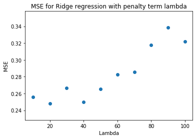

```python
lambda_range = np.arange(10, 110,10)
cvscores = [cross_validation_score(x_train, Y_train, folds_indexes,i) for i in lambda_range]
# Report best lambda and corresponding MSE

plt.scatter(lambda_range, cvscores)
plt.xlabel('Lambda')
plt.ylabel('MSE')
plt.title("MSE for Ridge regression with penalty term lambda")

lambda_best = lambda_range[np.argmin(cvscores)]
MSE_min = min(cvscores)
print("Mean squared error is minimised at", round(MSE_min,5), "and the optimal lambda is", lambda_best)
```

Let us zoom in near the optimum and grid search again.

[output not shown]

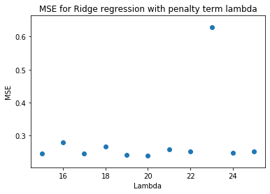

```python
lambda_range2 = lambda_best + np.arange(-5,6,1)
cvscores2 = [cross_validation_score(x_train, Y_train, folds_indexes,i) for i in lambda_range2]

plt.scatter(lambda_range2, cvscores2)
plt.xlabel('Lambda')
plt.ylabel('MSE')
plt.title("MSE for Ridge regression with penalty term lambda")


lambda_best = lambda_range[np.argmin(cvscores2)]
MSE_min = min(cvscores)
print("Mean squared error is minimised at", round(MSE_min,5), "and the optimal lambda is", lambda_best)
```

Now fix $\lambda$ and retrain on the entire training data, as well as the test data to obtain the coefficient of determination.

```python
betalasso = minimize_ls_huber(x_train, Y_train, lambda_best)
print ("In sample Coefficient of determination is:", round(Rsquared(Y_train, x_train ,betalasso),5))
print( "Out of sample Coefficient of determination is:", round(Rsquared(Y_test, x_test ,betalasso),5) )
```

```
In sample Coefficient of determination is: 0.81558
Out of sample Coefficient of determination is: 0.80579
```

```python
np.set_printoptions(suppress=True)
print("Beta parameters for Least squares regression:", beta)
print("Beta parameters for Ridge regression:", betaridge)
print("Beta parameters for Lasso regression:",betalasso)
```

```
Beta parameters for Least squares regression: [ 2.61638041  0.04471383  1.25871884 -0.03800928  0.36307345  0.00466535
  0.39051005 -0.07460286 -0.03570695 -0.01525883 -0.00180316]
Beta parameters for Ridge regression: [ 2.61123458  0.04585132  1.25789108 -0.03908974  0.36311335  0.00487071
  0.39063588 -0.07432832 -0.03562809 -0.01519212 -0.00048442]
Beta parameters for Lasso regression: [ 1.05725619  0.09265457  1.0082993  -0.00028468  0.3400176   0.00170042
  0.46666657 -0.00765942 -0.04476761 -0.00964892  0.31187864]
```

We observe that the parameters for lasso regression are noticably different to the other two methods. A much stronger sparsity is enforced, some of the parameters insignificant or very close to 0- this regularisation helps prevent overfitting and reduces the variance of the lasso regression estimator.

# Task 2: Classification ^

In this section we will looking at data on breast tumour samples, which can either be benign ("B") or malignant ("M"). T This output variable depends on 30 other features; we will be exploring different ways of modelling our train data and investigating how accurate it is on our test data. We will investigate how we can use k-nearest neighbours, random forests and SVMs(support vector machines) to model on our training data and check its accuracy against some test data.

## 2.1 ^ kNN Classifier

In this section we will use k-nearest neighbours to classify our data. We will work with continuous inputs and discrete ouputs, with data of the form $\{(x^{i}, y^{i}) \} , \: i = 1, \dots ,n $, where $x^i \in \mathbb{R}^{30}$ and $\: y^{i} \in \{0,1\}$. To make a prediction $\hat{y}$ on some input $x_{in}$,we use the following algorithm:

1. For i = 1,..,n, compute $\lVert x_{in} - x^{i} \rVert $, where $\lVert \rVert$ is the Euclidean metric
2. Compute k-nearest neighbours of $x_{in}$: $x^{i_1}, \dots , x^{i_n} $, by finding k smallest distances
3. Compute number of data of these k-nearest neighbours with output 0, or 1
4. Find class that most neighbours of $x_{in}$ belong to, and assign $\hat{y}$ to the corresponding class.

```python
def standardise(X_train, X_test):
    """Takes in dataset X and outputs normalised data"""
    # Normalise by column/covariate
    mu = np.mean(X_train, 0)
    sigma = np.std(X_train, 0)
    X_train_std = (X_train - mu) / sigma

    #Apply same transformation to test data
    X_test_std = (X_test - mu)/sigma
    return X_train_std, X_test_std
```

With the data we are working with, the scale or range can greatly vary depending on the covariate. To prevent one covariate for having a disproportionately large effect on the model, we standardise our data. To transform the training data, we subtract by its sample mean and divide by its sample variance, column-wise. This is the equivalent of modelling on a linear transformation of the predictors, so we apply the identical transformation to the test data.

For the output class, "M" is transformed to 1, and 1 to "B", to make calculations easier.

```python
#Load data
tumour_sample = pd.read_csv("tumour_samples.csv")
tumour_test = pd.read_csv("tumour_test.csv")

#Get rid of column of indexes
tumour_sample = tumour_sample.drop(tumour_sample.columns[0], axis=1)
tumour_test = tumour_test.drop(tumour_test.columns[0], axis=1)

#set train and test data, and convert to arrays
#Standardise input data
#transform "B" to 1, otherwise 0
X_train = pd.DataFrame.to_numpy( tumour_sample.drop("DIAGNOSIS", axis = 1) )
X_test = pd.DataFrame.to_numpy( tumour_test.drop("DIAGNOSIS", axis = 1) )
X_train, X_test = standardise(X_train, X_test)


Y_train = np.array([1 if i=="M" else 0 for i in pd.DataFrame.to_numpy(tumour_sample["DIAGNOSIS"])])
Y_test = np.array([1 if i == "M" else 0 for i in  pd.DataFrame.to_numpy(tumour_test["DIAGNOSIS"])])
```

To perform the k-nearest neighbours algorithm, we first create a function that can compute the Euclidean distance between two data points. We will also be performing T-fold cross validation, so we shuffle the training data and create 5 folds. As we have 2566 data points, the 5th fold will have one extra data point.

```python
def euclidian_distance(p, q):
    """Compute distance between p and q - row-wise if p and q are matrices"""
    return np.sqrt(np.sum((p-q)**2, axis=1))

#Training data will be split into roughly 5 equally sized folds after shuffling
p = np.random.permutation(len(Y_train))
X_train = X_train[p]
Y_train = Y_train[p]
folds_indexes = np.split(np.arange(len(Y_train)), [513,1026,1539,2052])
```

Now we can use this to create a function that finds the k-nearest neighbours in the training data of the test data. We iterate over every data point in the training data, computing the euclidean distances and finding the indexes for the 5 smallest distances.

```python
def k_neighbours(X_train, X_test, k=5, return_distance=False):
  """ Outputs matrix where row i represents the k nearest neighbours of i'th
  data point in X_train to X_test"""
  n_neighbours = k
  dist = []
  neigh_ind = []

  # compute distance from each point x_test in X_test to all points in X_train
  point_dist = [euclidian_distance(x_test, X_train) for x_test in X_test]

  # determine which k training points are closest to each test point
  for row in point_dist:
      enum_neigh = enumerate(row)
      sorted_neigh = sorted(enum_neigh, key=lambda x: x[1])[:k]

      ind_list = [tup[0] for tup in sorted_neigh]
      dist_list = [tup[1] for tup in sorted_neigh]

      dist.append(dist_list)
      neigh_ind.append(ind_list)

  # return distances together with indices of k nearest neighbours
  if return_distance:
      return np.array(dist), np.array(neigh_ind)

  return np.array(neigh_ind)
```

The predict function uses the k_neighbours function, outputting the majority class within the k nearest neighbours.

```python
def predict(X_train, y_train, X_test, k=5):
  """ Train model on X_train and y_train, predict output of X_test"""

  # each of the k neighbours contributes equally to the classification of any data point in X_test
  neighbours = k_neighbours(X_train, X_test, k=k)

  # count number of occurences of label with np.bincount and choose the label that has most
  y_pred = np.array([np.argmax(np.bincount(y_train[neighbour])) for neighbour in neighbours])

  return y_pred
```

We need a new score function that computes the accuracy of the prediction from kNN classification, which can be used for 5 fold cross-validation.

```python
def score(X_train, y_train, X_test, y_test, k=5):
  """Output proportion of correctly predicted outputs of X_test by comparing to Y_test"""
  y_pred = predict(X_train, y_train, X_test, k=k)
  return np.float(sum(y_pred==y_test))/ float(len(y_test))
```

```python
def cross_validation_score(x_train, Y_train, folds, k):
  """ Compute cross validation score across training data, performing k-nearest neighbours for each fold"""
  scores = []
  for i in range(len(folds)):

    # Set fold S_k out of one of the 5 folds, and store its complement
    val_indexes = folds[i]
    train_indexes = list(set(range(Y_train.shape[0])) - set(val_indexes))

    x_train_i = x_train[train_indexes, :]
    Y_train_i = Y_train[train_indexes]

    x_val_i = x_train[val_indexes, :]
    Y_val_i = Y_train[val_indexes]

    #Compute accuracy of fit on fold data
    score_i = score(x_train_i, Y_train_i, x_val_i, Y_val_i, k=k)
    scores.append(score_i)

  # Return the mean squared error over all 5 folds
  return sum(scores)/len(scores)
```

Now we can perform hyperparameter tuning, running k from 1 to 20 and outputting the k that maximises the mean accuracy across the folds.

```
Mean accuracy is maximised at 0.9961 and the optimal k is 1
```

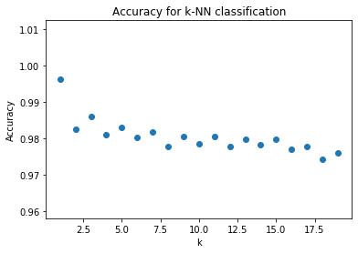

```python
k_range = np.arange(1,20,1)
cvscores = [cross_validation_score(X_train, Y_train, folds_indexes,i) for i in k_range]

plt.scatter(k_range, cvscores)
plt.ylabel('Accuracy')
plt.xlabel('k')
plt.title("Accuracy for k-NN classification")
# Report best k and corresponding accuracy

k_best = k_range[np.argmax(cvscores)]
accuracy_max = max(cvscores)
print("Mean accuracy is maximised at", round(accuracy_max,5), "and the optimal k is", k_best)
```

Using the optimal k, we now model on all the training data and use it to predict on the test data.

```python
print('Train set accuracy:', score(X_train, Y_train, X_train, Y_train, k=k_best))
print('Test set accuracy:', score(X_train, Y_train, X_test, Y_test, k=k_best))
```

```
Train set accuracy: 1.0
Test set accuracy: 1.0
```

For both the test and train set, the k-NN classifer makes completely accurate predictions. Naturally, the accuracy on the training set is 1 because the nearest neighbour of any data point is itself. Our optimal k is 1, and initially this may suggest that overfitting has occured. However, we worked with a very large dataset (2566 samples from training data) and the CV score for other values of k is still very high. In this situation, k-NN classification can accurately perform binary classification because of the distinct effect breast tumour samples has on the remaining covariates.

## 2.2 ^ Random forests

Random forests are an extension of decision trees. Our goal is to partition the input domain into subsets $R_1,..,R_k$ for some k, where these subsets mostly contain elements of one class. We can then use the majority rule to make predictions- we observe which region $R_{i}$ some out of sample input $x_{in}$ belongs to, and predict $\hat{y}$ to be the most common class in $R_i.$

$$ CE(\pi(R)) = -\sum_{q} \pi_q(R) \log(\pi_q(R))$$

where we denote $\pi_q(R)$ to be the proportion of data points in R that belong to class q.

We can create an ensemble of decision trees by creating B models, where each tree is modelled from a random sample of size N' < N. To make a prediction with multiple trees, we instead compute the average vector $\pi(R_i)$ across every tree where $x_{in} \in R_i$ and predict $\hat{y}$ to be the class with the highest corresponding proportion.

Note that if the depth of these trees is too large then overfitting will occur, so we will explore how the hyperparameters tree depth and number of trees affect the model. We do not standardise the data- partitioning data is not affected by standardisation.

```python
#1 represents "M", 0 represents "B"
X_train = pd.DataFrame.to_numpy( tumour_sample.drop("DIAGNOSIS", axis = 1) )
Y_train = np.array([1 if i=="M" else 0 for i in tumour_sample["DIAGNOSIS"]])

X_test = pd.DataFrame.to_numpy( tumour_test.drop("DIAGNOSIS", axis = 1) )
Y_test = np.array([1 if i == "M" else 0 for i in tumour_test["DIAGNOSIS"]])
```

We first create a function to calculate the the cross entropy of a subset of the data.

```python
def CE(y):
  """ Calculate the cross entropy for subset y"""
  ratio = np.sum(y)/len(y)
  if ratio in [0,1]:
    return 0
  else:
    props = np.array([ratio,1 - ratio])
    return -np.dot(props, np.log(props))
```

Now we can split at given column value and index.

```python
def split_samples(X, y, column, value):
  """ Splits at a given column index and value, outputting the two new subsets"""

  left_mask = (X[:, column] < value)

  X_left, X_right = X[left_mask, :], X[~left_mask, :]
  y_left, y_right = y[left_mask], y[~left_mask]

  return (X_left, X_right), (y_left, y_right)
```

```python
def CE_split_value(X, y, column):
  """Calculate the cross entropy based on a given column with the split that minimizes the CE."""

  unique_vals = np.unique(X[:, column])

  assert len(unique_vals) > 1, f"There must be more than one distinct feature value. Given: {unique_vals}."

  CE_val, threshold = np.inf, None

  # split the values of i-th feature and calculate the cost
  for value in unique_vals:
    (X_l, X_r), (y_l, y_r) = split_samples(X, y, column, value)

    # if one of the two sides is empty, skip this split.
    if len(y_l) == 0 or len(y_r) == 0:
      continue

    p_left = len(y_l)/(sum(y_l) + sum(y_r))
    p_right = 1 - p_left
    new_cost = p_left * CE(y_l) + p_right * CE(y_r)
    if new_cost < CE_val:
      CE_val, threshold = new_cost, value

  return CE_val, threshold

def majority_vote(y):
  """Output class is either 0 or 1, returns class that is most common"""
  if sum(y) >= len(y)/2:
    return 1
  else:
    return 0
```

We now create a decision tree. As we have 30 covariates, we will always sample from 10 features(a third of 30), this is typically the ideal ratio for random forest classification.

```python
def CE_split_rf(n_features, X, y):
  """
  Choose the best feature to split according to criterion.
  Args:
      n_features: number of sampled features.
      X: training features, of shape (N, D).
      y: vector of training labels, of shape (N,).
      sample_weights: weights for each samples, of shape (N,).
      columns_dict: a dictionary mapping column indices to whether the column is categorical or numerical variable.
  Returns:
      (float, int, float): the minimized gini-index, the best feature index and value used in splitting.
  """
  columns_dict = {index: False for index in range(X_train.shape[1])}
  columns = np.random.choice(list(columns_dict.keys()), n_features, replace=False)
  columns_dict = {c: columns_dict[c] for c in columns}

  min_CE_index, split_column, split_val = np.inf, 0, 0
  for column, categorical in columns_dict.items():
    # skip column if samples are not seperable by that column.
    if len(np.unique(X[:, column])) < 2:
      continue

    # search for the best splitting value for the given column.
    CE_index, val = CE_split_value(X, y, column)
    if CE_index < min_CE_index:
        min_CE_index, split_column, split_val = CE_index, column, val

  return min_CE_index, split_column, split_val
```

```python
feature_names = tumour_sample.drop("DIAGNOSIS", axis = 1).columns.tolist()

def build_tree_rf(n_features, X, y, feature_names, depth, max_depth=10, min_samples_leaf=1):
  """Build the decision tree according to the data.
  Args:
      X: (np.array) training features, of shape (N, D).
      y: (np.array) vector of training labels, of shape (N,).
      sample_weights: weights for each samples, of shape (N,).
      columns_dict: a dictionary mapping column indices to whether the column is categorical or numerical variable.
      feature_names (list): record the name of features in X in the original dataset.
      depth (int): current depth for this node.
  Returns:
      (dict): a dict denoting the decision tree (binary-tree). Each node has seven attributes:
        1. 'feature_name': The column name of the split.
        2. 'feature_index': The column index of the split.
        3. 'value': The value used for the split.
        4. 'categorical': indicator for categorical/numerical variables.
        5. 'majority_label': For leaf nodes, this stores the dominant label. Otherwise, it is None.
        6. 'left': The left sub-tree with the same structure.
        7. 'right' The right sub-tree with the same structure.
      Example:
          mytree = {
              'feature_name': 'petal length (cm)',
              'feature_index': 2,
              'value': 3.0,
              'categorical': False,
              'majority_label': None,
              'left': {
                  'feature_name': str,
                  'feature_index': int,
                  'value': float,
                  'categorical': bool,
                  'majority_label': None,
                  'left': {..etc.},
                  'right': {..etc.}
              }
              'right': {
                  'feature_name': str,
                  'feature_index': int,
                  'value': float,
                  'categorical': bool,
                  'majority_label': None,
                  'left': {..etc.},
                  'right': {..etc.}
              }
          }
  """
  columns_dict = {index: False for index in range(X_train.shape[1])}
  # include a clause for the cases where (i) all lables are the same, (ii) depth exceed (iii) X is too small
  if len(np.unique(y)) == 1 or depth>=max_depth or len(X)<=min_samples_leaf:
      return {'majority_label': majority_vote(y)}

  else:
    CE, split_index, split_val = CE_split_rf(n_features, X, y)

    # If GI is infinity, it means that samples are not seperable by the sampled features.
    if CE == np.inf:
      return {'majority_label': majority_vote(y)}
    (X_l, X_r), (y_l, y_r) = split_samples(X, y, split_index, split_val)
    return {
        'feature_name': feature_names[split_index],
        'feature_index': split_index,
        'value': split_val,
        'majority_label': None,
        'left': build_tree_rf(n_features, X_l, y_l, feature_names, depth + 1, max_depth, min_samples_leaf),
        'right': build_tree_rf(n_features, X_r, y_r, feature_names, depth + 1, max_depth, min_samples_leaf)
    }
```

We output an example random forest, where the indentation refers to the depth within the tree.

```python
build_tree_rf(10, X_train, Y_train, feature_names, 1, max_depth=5, min_samples_leaf=1)
```

```
{'feature_name': 'n3_perimeter',
 'feature_index': 22,
 'value': 101.29743990000001,
 'majority_label': None,
 'left': {'feature_name': 'n3_area',
  'feature_index': 23,
  'value': 809.7767087999999,
  'majority_label': None,
  'left': {'feature_name': 'n1_concave_points',
   'feature_index': 7,
   'value': 0.079015318,
   'majority_label': None,
   'left': {'feature_name': 'n1_radius',
    'feature_index': 0,
    'value': 15.12996949,
    'majority_label': None,
    'left': {'majority_label': 0},
    'right': {'majority_label': 1}},
   'right': {'feature_name': 'n2_radius',
    'feature_index': 10,
    'value': 0.644316233,
    'majority_label': None,
    'left': {'majority_label': 1},
    'right': {'majority_label': 0}}},
  'right': {'feature_name': 'n3_perimeter',
   'feature_index': 22,
   'value': 99.17458791,
   'majority_label': None,
   'left': {'majority_label': 1},
   'right': {'majority_label': 0}}},
 'right': {'feature_name': 'n1_concave_points',
  'feature_index': 7,
  'value': 0.047443899000000005,
  'majority_label': None,
  'left': {'feature_name': 'n3_radius',
   'feature_index': 20,
   'value': 18.03786138,
   'majority_label': None,
   'left': {'feature_name': 'n2_concave_points',
    'feature_index': 17,
```

[output cut: 11 more lines]

```
   'feature_index': 23,
   'value': 951.9615717,
   'majority_label': None,
   'left': {'feature_name': 'n3_concavity',
    'feature_index': 26,
    'value': 0.264725642,
    'majority_label': None,
    'left': {'majority_label': 0},
    'right': {'majority_label': 1}},
   'right': {'feature_name': 'n3_concavity',
    'feature_index': 26,
    'value': 0.210345096,
    'majority_label': None,
    'left': {'majority_label': 1},
    'right': {'majority_label': 1}}}}}
```

We now create multiple trees to build a random forest.

```python
def train_rf(B, n_features, depth, X, y):
  """
  Build the decision tree according to the training data.
  Args:
      B: number of decision trees.
      X: (pd.Dataframe) training features, of shape (N, D). Each X[i] is a training sample.
      y: (pd.Series) vector of training labels, of shape (N,). y[i] is the label for X[i], and each y[i] is
      an integer in the range 0 <= y[i] <= C. Here C = 1.
      columns_dict: a dictionary mapping column indices to whether the column is categorical or numerical variable.
  """

  N = X.shape[0]
  training_indices = np.arange(N)
  trees = []

  for _ in range(B):
    sample = np.random.choice(training_indices, N, replace=True)
    #Append decision tree based of sample of training data
    X_sample = X[sample, :]
    y_sample = y[sample]
    tree = build_tree_rf(n_features, X_sample, y_sample, feature_names, depth)
    trees.append(tree)

  return trees
```

```python
from collections import defaultdict

def classify(tree, x):
  """
  Classify a single sample with the fitted decision tree.
  Args:
      x: ((pd.Dataframe) a single sample features, of shape (D,).
  Returns:
      (int): predicted testing sample label.
  """
  if tree['majority_label'] is not None:
    return tree['majority_label']
  else:
    if x[tree['feature_index']] < tree['value']:
      return classify(tree['left'], x)
    else:
      return classify(tree['right'], x)
```

The predict function aggregates over the ensemble of trees.

```python
def predict_rf(rf, X):
  """
  Predict classification results for X.
  Args:
      rf: A trained random forest through train_rf function.
      X: (pd.Dataframe) testing sample features, of shape (N, D).
  Returns:
      (np.array): predicted testing sample labels, of shape (N,).
  """
  # Aggregate over all models

  def aggregate(decisions):
    count = defaultdict(int)
    for decision in decisions:
      count[decision] += 1
    return max(count, key=count.get)


  if len(X.shape) == 1:
      return aggregate([classify(tree, X) for tree in rf])
  else:
      return np.array([aggregate([classify(tree, x) for tree in rf]) for x in X])

def rf_score(rf, X_test, y_test):
  y_pred = predict_rf(rf, X_test)
  return np.mean(y_pred==y_test)
```

```python
rf = train_rf(1, 10,1, X_train, Y_train)
rf_score(rf, X_train, Y_train)
```

```
0.9886983632112237
```

Now implement 5-fold cross validation on our training data- using the same folds as in 2.1.1, we will obtain an ensemble of decision trees and compute the mean accuracy, for some given number of trees and tree depth.

```python
def cross_validation_score(x_train, Y_train, folds, trees, depth):
  """ Compute cross validation score across training data, performing k-nearest neighbours for each fold"""
  scores = []
  for i in range(len(folds)):

    # Set fold S_k out of one of the 5 folds, and store its complement
    val_indexes = folds[i]
    train_indexes = list(set(range(Y_train.shape[0])) - set(val_indexes))

    x_train_i = x_train[train_indexes, :]
    Y_train_i = Y_train[train_indexes]

    x_val_i = x_train[val_indexes, :]
    Y_val_i = Y_train[val_indexes]


    #Compute accuracy of fit on fold data
    rf_ = train_rf(trees, 10,depth, x_train_i, Y_train_i)
    score_i = rf_score(rf_, x_val_i, Y_val_i)
    scores.append(score_i)

  # Return the mean squared error over all 5 folds
  return sum(scores)/len(scores)
```

Now scan for the optimal hyperparameters by sending the number of trees and tree depth from 1-5, and find output the maximum mean accuracy on the training data.

```python
B_range = np.arange(1,6,1)
depth_range = np.arange(1,6,1)
cvscores = np.zeros((len(B_range),len(depth_range)))

for i in B_range:
    for j in depth_range:
        cvscores[(i-1),(j-1)] = cross_validation_score(X_train, Y_train, folds_indexes, i, j)
```

We now plot the CV score near its maximum to visualise the behaviour near the optimal hyperparameters. We fix for the optimal number of decision trees and vary the tree depth, then fix for the optimal tree depth and vary the number of decision trees.

```
Mean accuracy is maximised at 0.98246 , the optimal number of trees is 5  and optimal depth is 3
```

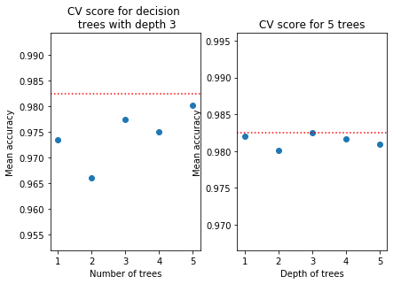

```python
#Search for best hyperparameters and output
accuracy_max = np.amax(cvscores)
B_best, depth_best = np.where(cvscores == accuracy_max)
# add 1 to convert from index to value
B_best = B_best[0] + 1
depth_best = depth_best[0] + 1
print("Mean accuracy is maximised at",round(accuracy_max,5),
      ", the optimal number of trees is", B_best," and optimal depth is", depth_best)


fig, (ax1, ax2) = plt.subplots(1, 2)
fig.tight_layout()

ax1.scatter(np.arange(1,6), cvscores[:,1])
ax1.axhline(y=accuracy_max, color='r', linestyle=':')
ax1.set_xlabel("Number of trees")
ax1.set_ylabel("Mean accuracy")
ax1.set_title("CV score for decision \n trees with depth {}".format(depth_best))

ax2.scatter(np.arange(1,6), cvscores[4,:])
ax2.axhline(y=accuracy_max, color='r', linestyle=':')
ax2.set_xlabel("Depth of trees")
ax2.set_ylabel("Mean accuracy")
ax2.set_title("CV score for {} trees".format(B_best))
```

Now that we have found the optimal parameters, we now check the accuracy on all training data, and the test data.

```python
rf_ = train_rf(B_best, 10, depth_best, X_train, Y_train)
print('Train set mean accuracy:', round(rf_score(rf_, X_train, Y_train),5))
print('Test set mean accuracy:', round(rf_score(rf_, X_test, Y_test),5))
```

```
Train set mean accuracy: 0.99571
Test set mean accuracy: 0.975
```

```python
act_train = pd.Series(Y_train, name='Actual')
pred_train = pd.Series(predict_rf(rf_, X_train), name='Predicted')
confusion_train = pd.crosstab(act_train, pred_train)

act_test = pd.Series(Y_test, name='Actual')
pred_test = pd.Series(predict_rf(rf_, X_test), name='Predicted')
confusion_test = pd.crosstab(act_test, pred_test)
```

```python
confusion_train
```

| Predicted Actual | 0 | 1 |
| --- | --- | --- |
| 0 | 2141 | 1 |
| 1 | 10 | 414 |

```python
confusion_test
```

| Predicted Actual | 0 | 1 |
| --- | --- | --- |
| 0 | 127 | 0 |
| 1 | 5 | 68 |

The true positve rate(or recall), precision and F-score are defined as follows:

$$ \text{recall} = \frac{TP}{TP+FN} \quad \text{precision} = \frac{TP}{TP+FP} \quad F = 2 \frac{\text{precision}*\text{recall}}{\text{precision} + \text{recall}}$$

These quantities range from 0 to 1, and the larger they are, the more accurate the model is. We compute the recall and F-scores for our training and test data.

```python
def prediction_rates(y_pr, y_ac):
    # true positives
    tp = np.sum(np.logical_and(y_pr == 1, y_ac == 1))
    # true negatives
    tn = np.sum(np.logical_and(y_pr == 0, y_ac == 0))
    # false positives
    fp = np.sum(np.logical_and(y_pr == 1, y_ac == 0))
    # false negatives
    fn = np.sum(np.logical_and(y_pr == 0, y_ac == 1))
    #recall
    recall = tp / (tp + fn)
    #predict
    precision = tp / (tp + fp)
    F_score = 2*(precision*recall)/(precision+recall)
    return recall, F_score

r1, f1 = prediction_rates(predict_rf(rf_, X_train), Y_train)
r2, f2 = prediction_rates(predict_rf(rf_, X_test), Y_test)

print("Training data recall is", round(r1,5))
print("Test data recall is", round(r2,5))
print("Training data F-score is", round(f1,5))
print("Test data F-score is", round(f2,5))
```

```
Training data recall is 0.97642
Test data recall is 0.93151
Training data F-score is 0.98689
Test data F-score is 0.96454
```

The smaller the number of false negatives are, the closer the recall is to 1. The training and test recalls exceed 0.93 which is high, but in cancer screening, this would not be high enough alone to make confident classifications.

The F-score, which is the harmonic mean of the recall and precision, is also over 0.96 for both our test and training data. The model is more accurate on the training data than it is on the test data, so perhaps random forests are not as accurate to generalising out of sample like kNN neighbours can.

## 2.3 ^ Support Vector Machine

In this section we use soft-margin SVMs (support vector machines), where our goal is to find a hyperplane $\boldsymbol w \cdot x_i + b$ that can split the input domain into two subsets that are as homogenous in class as possible - the output is 1 or -1. We do this my minimising the loss function $$ \mathcal L (\boldsymbol w) = \frac{1}{2} \| \boldsymbol w \|^2 + \frac{\lambda}{n} \sum_{i=1}^n \max \bigg( 0, 1-y_i (\boldsymbol w \cdot x_i + b) \bigg) \, . $$

When performing soft-margin SVM's the hardness parameter $\lambda$ controls the penalty term that measures how imperfect the seperation of the data is. If we could split our data into two seperate classes with one plane, then $y^{(i)}(x^{(i)}*w + b) \geq 1$ for all points, meaning that the loss function would just $L(w) = \frac{1}{2} \lVert w \rVert^2$. The larger the hardness parameter is, the more the constraint violations are penalised and the more representative it becomes of hard-margin SVM.

```python
#Ignore output data, convert to array and standardise
X_train = pd.DataFrame.to_numpy( tumour_sample.drop("DIAGNOSIS", axis = 1) )
X_test = pd.DataFrame.to_numpy( tumour_test.drop("DIAGNOSIS", axis = 1) )
X_train, X_test = standardise(X_train, X_test)

#1 represents "B", -1 represents "M"
Y_train = np.array([1 if i=="M" else -1 for i in tumour_sample["DIAGNOSIS"]])
Y_test = np.array([1 if i == "M" else -1 for i in tumour_test["DIAGNOSIS"]])
```

We now define the loss function. We will add a column of 1s to X so that the intercept term b is included in w, the vector of weights.

```python
X_train = np.hstack(( np.ones((X_train.shape[0],1)), X_train ))
X_test = np.hstack(( np.ones((X_test.shape[0],1)), X_test ))
```

```python
def compute_cost(w, X, y, hardness=1e5):
    distances = 1 - y * (X @ w)
    distances[distances < 0] = 0  #  max(0, distance)
    hinge = hardness * distances.mean()
    # calculate cost
    return 0.5 * np.dot(w, w) + hinge
```

The score function checks the accuracy of our predictions. We look at what side of the hyperplane $x_{in}$ is by computing the sign of $x_{in} \cdot w$. If it is positive, $\hat{y} = 1$, otherwise $\hat{y}= -1.$

```python
def score(w, X, y):
    y_preds = np.sign(X @ w)
    return np.mean(y_preds == y)
```

The minimum to the loss function cannot be analytically found so we use stochastic gradient descent. We set our step size $\eta_k$ to be equal to $\frac{C}{k}$, where C is some constant (the learning rate) and k is the number of iterations. This prevents the loss function from rapidly oscillating above and below the global optimum, which may happen otherwise if a fixed step size is used. Whenever the iteration number is of the form $2^k$, we will also output the cost and accuracy.

```python
def calculate_cost_gradient(w, X_batch, y_batch, hardness=1e5):
    # if only one example is passed
    if type(y_batch) == np.int32:
        y_batch = np.asarray([y_batch])
        X_batch = np.asarray([X_batch])  # gives multidimensional array

    distance = 1 - (y_batch * (X_batch @ w))
    dw = np.zeros(len(w))

    for ind, d in enumerate(distance):
        if max(0, d)==0:
            di = w
        else:
            di = w - (hardness * y_batch[ind] * X_batch[ind])
        dw += di

    return dw/len(y_batch)  # average
```

```python
def sgd(X, y, batch_size=16, max_iterations=5000, stop_criterion=0, learning_rate=7.5e-4, hardness=1e5, print_outcome=False):
    # initialise zero weights
    weights = np.zeros(X.shape[1])
    nth = 0
    # initialise starting cost as infinity
    prev_cost = np.inf

    # stochastic gradient descent
    indices = np.arange(len(y))
    for iteration in np.arange(1, max_iterations):
        # shuffle to prevent repeating update cycles
        np.random.shuffle(indices)
        batch_idx = indices[:batch_size]
        X_b, y_b = X[batch_idx], y[batch_idx]
        for xi, yi in zip(X_b, y_b):
            ascent = calculate_cost_gradient(weights, xi, yi, hardness)
            weights = weights - (learning_rate/iteration)*ascent

        # convergence check on 2^n'th iteration
        if iteration==2**nth or iteration==max_iterations-1:
            # compute cost
            cost = compute_cost(weights, X, y, hardness)
            if print_outcome:
                print("Iteration is: {}, Cost is: {}, Score is {}".format(iteration, cost, score(weights, X, y) ))
            # stop criterion
            if abs(prev_cost - cost) < stop_criterion * prev_cost:
                return weights

            prev_cost = cost
            nth += 1

    return weights
```

Run the stochastic gradient descent function with some random parameters- cost is outputted whenever the iterations = $2^n$ and terminates if convergence is failing.

```python
w = sgd(X_train, Y_train, batch_size=32, max_iterations=10000, stop_criterion=0.01,
        learning_rate=7.5e-4, hardness=70, print_outcome=True)
print("Training finished.")
```

```
Iteration is: 1, Cost is: 23.784460301250117, Score is 0.8620420888542478
Iteration is: 2, Cost is: 19.304834712020586, Score is 0.8990646921278254
Iteration is: 4, Cost is: 14.131709069713631, Score is 0.9255650818394389
Iteration is: 8, Cost is: 10.957870677532432, Score is 0.9505066250974279
Iteration is: 16, Cost is: 7.755771082486646, Score is 0.9692127825409197
Iteration is: 32, Cost is: 6.770879346453132, Score is 0.9723304754481683
Iteration is: 64, Cost is: 6.03407618896048, Score is 0.9770070148090413
Iteration is: 128, Cost is: 5.78752837050963, Score is 0.9793452844894778
Iteration is: 256, Cost is: 5.649441916691543, Score is 0.9797349961028838
Iteration is: 512, Cost is: 5.514853931769537, Score is 0.9801247077162899
Iteration is: 1024, Cost is: 5.419812682537058, Score is 0.9812938425565082
Iteration is: 2048, Cost is: 5.341673531075781, Score is 0.9832424006235386
Iteration is: 4096, Cost is: 5.286118425460924, Score is 0.9836321122369447
Iteration is: 8192, Cost is: 5.244036801172397, Score is 0.9844115354637568
Training finished.
```

```python
print("Accuracy on train set: {}".format(score(w, X_train, Y_train)))
print("Accuracy on test set: {}".format(score(w, X_test, Y_test)))
```

```
Accuracy on train set: 0.9844115354637568
Accuracy on test set: 0.97
```

We will create a function that lets us perform T-fold cross-validation for some given hardness parameter, using the same folds as in section 2.1 and 2.2. The score function computes the accuracy by calculating the proportion of correctly predicted outputs.

```python
def cross_validation_score(x_train, Y_train, folds, hardness, max_iterations=5000): #average accuracy across T=5 folds
  """ Compute cross validation score across training data, performing SVM classification
  with penalty term lamda """
  scores = []
  for i in np.arange(len(folds)):

    # Set fold S_k out of one of the 5 folds, and store its complement
    val_indexes = folds[i]
    train_indexes = list(set(range(Y_train.shape[0])) - set(val_indexes))

    x_train_i = x_train[train_indexes, :]
    Y_train_i = Y_train[train_indexes]

    x_val_i = x_train[val_indexes, :]
    Y_val_i = Y_train[val_indexes]

    weights = sgd(x_train_i, Y_train_i, batch_size=16, hardness = hardness,
                  max_iterations = max_iterations,print_outcome=False)
    score_i = score(weights, x_val_i, Y_val_i)

    scores.append(score_i)

  # Return the mean squared error over all 5 folds
  return sum(scores)/len(scores)

cross_validation_score(X_train, Y_train, folds_indexes, max_iterations= 2000, hardness=5e4)
```

```
0.9793425413945587
```

Now we scan for the optimal hardness parameter, checking for $\lambda = 5,10,..,100$ and then zooming in near the $\lambda$ that gives the largest CV score and performing 2nd grid search.

```
Mean accuracy is maximised at 0.98402 and the optimal hardness is 46
```

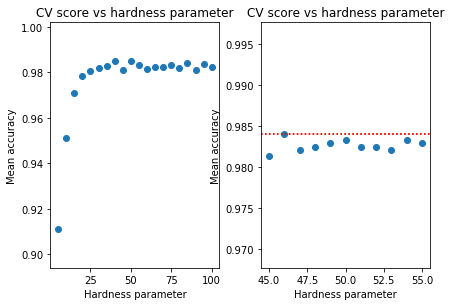

```python
fig, (ax1, ax2) = plt.subplots(1, 2)
fig.tight_layout()

#Scan across large range for optimal hardness
hardness_range = np.arange(5,105,5)
cvscores = [cross_validation_score(X_train, Y_train, folds_indexes,i) for i in hardness_range]

#Zoom in and scan near maximum CV score of first scan
hardness_range2 = hardness_range[np.argmax(cvscores)] + np.arange(-5,6,1)
cvscores2 = [cross_validation_score(X_train, Y_train, folds_indexes,i) for i in hardness_range2]

hardness_best = hardness_range2[np.argmax(cvscores2)]
accuracy_max = max(cvscores2)

ax1.scatter(hardness_range, cvscores)
ax1.set_xlabel("Hardness parameter")
ax1.set_ylabel("Mean accuracy")
ax1.set_title("CV score vs hardness parameter")
ax2.axhline(y=accuracy_max, color='r', linestyle=':')

ax2.scatter(hardness_range2, cvscores2)
ax2.set_xlabel("Hardness parameter")
ax2.set_ylabel("Mean accuracy")
ax2.set_title("CV score vs hardness parameter")
ax2.axhline(y=accuracy_max, color='r', linestyle=':')

# Report best hardness and corresponding accuracy
print("Mean accuracy is maximised at", round(accuracy_max,5), "and the optimal hardness is", hardness_best)
```

Fix for optimal hardness, then retrain on full training data and test data

```python
weights = sgd(X_train, Y_train, batch_size=16, max_iterations=10000, stop_criterion=0.01, learning_rate=7.5e-4,
              hardness=hardness_best, print_outcome=False)
print('Train set accuracy:', round(score(weights, X_train, Y_train),5))
print('Test set accuracy:', round(score(weights, X_test, Y_test),5))
```

```
Train set accuracy: 0.98246
Test set accuracy: 0.955
```

```python
def roc_curve(x_train, y_train, x_test, y_test, hardness):

  tpr_l, fpr_l = [], []

  #Train model on training data with given hardness
  weights = sgd(x_train, y_train, batch_size=32, max_iterations=1000, stop_criterion=0.01,
        learning_rate=7.5e-4, hardness=hardness, print_outcome=False)

  #Predict on test data
  Y_prob = x_test @ weights

  #Convert output classes from 1s and 0s to 1s and -1s to make calculations easier
  Y_test = np.array([1 if i==1 else 0 for i in y_test])

  thresholds = reversed(sorted(set(Y_prob)))
  for threshold in thresholds:
    # Apply thresholding
    y_thresholded = (Y_prob >= threshold)

    # true positives
    tp = np.sum(Y_test & y_thresholded)
    # true negatives
    tn = np.sum((~Y_test) & (~y_thresholded))
    # false positives
    fp = np.sum((~Y_test) & y_thresholded)
    # false negatives
    fn = np.sum(Y_test & (~y_thresholded))

    tpr = tp / (tp + fn)
    fpr = fp / (tn + fp)
    tpr_l.append(tpr)
    fpr_l.append(fpr)

  # Compute AUC using Trapezoidal rule
  auc = np.trapz(tpr_l, fpr_l)
  return auc, tpr_l, fpr_l, thresholds
```

We now the make ROC plots for some hardness values centered about the optimal hardness. We also plot the AUC, the area under the curve which ranges between 0 and 1 and quantifies the accuracy of the model.

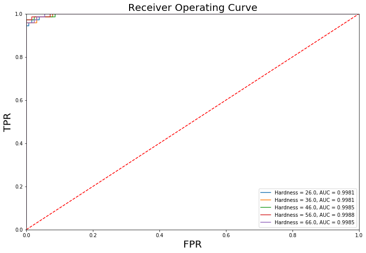

```python
range_hardness = hardness_best + np.linspace(-20,20,5)

plt.figure(figsize=(12,8))
plt.title(f"Receiver Operating Curve", size=20)
plt.ylabel('TPR', size=20)
plt.xlabel('FPR', size=20)
plt.xlim([0, 1])
plt.ylim([0, 1])

plt.plot([0, 1], [0, 1],'r--')
for i in range_hardness:
    auc, tpr, fpr, th = roc_curve(X_train, Y_train, X_test, Y_test, i)
    plt.plot(fpr, tpr,label = f"Hardness = {i}, AUC = {auc:0.4f}")

plt.legend(loc = 'lower right')
plt.show()
```

In all ROC curves, the AUC is close to 1, which suggests that we can consistently maintain high accuracy in our predictions, even if we use a wide range of values for the hardness parameter, as long as we use sufficiently large iterations and an appropiate learning rate in our stochastic gradient descent to ensure convergence.

Lets now repeat our modelling from section 2.3 so far on a new set of balanced data, and train a new model. This data has 800 data points, with 400 belonging to each of the two classes.

```python
#Load unbalanced data and drop column of indexes
tumour_bal = pd.read_csv("tumour_samples_bal.csv")
tumour_bal = tumour_bal.drop(tumour_bal.columns[0], axis = 1)

#reload balanced(training) data and test data
X_train_bal = pd.DataFrame.to_numpy( tumour_bal.drop("DIAGNOSIS", axis = 1) )
X_test = pd.DataFrame.to_numpy( tumour_test.drop("DIAGNOSIS", axis = 1) )
#standardise
X_train_bal, X_test = standardise(X_train_bal, X_test)
# add column of 1s for intercept in SVM
X_train_bal = np.hstack(( np.ones((X_train_bal.shape[0],1)), X_train_bal ))
X_test = np.hstack(( np.ones((X_test.shape[0],1)), X_test ))

#Load training data output
Y_train_bal = np.array([1 if i=="M" else -1 for i in tumour_bal["DIAGNOSIS"]])
```

To perform 5-fold cross validation, we will need to create a new set of fold indexes as the balanced data has a different number of rows.

```python
#Shuffle rows
p = np.random.permutation(len(Y_train_bal))
X_train_bal = X_train_bal[p]
Y_train_bal = Y_train_bal[p]

#folds are index 0-159, .., 640-799
folds_bal = np.split(np.arange(len(Y_train_bal)), [160,320,480,640])
```

We scan for the optimal hyperparameter again, applying SVM of varying hardness to the training balanced data.

```
Mean accuracy is maximised at 0.97 and the optimal k is 70
```

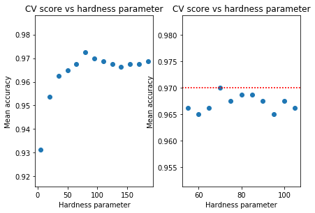

```python
fig, (ax1, ax2) = plt.subplots(1, 2)
fig.tight_layout()

#Scan across large range for optimal hardness
hardness_range = np.arange(5,200,15)
cvscores = [cross_validation_score(X_train_bal, Y_train_bal, folds_bal,i) for i in hardness_range]

#Zoom in and scan near maximum CV score of first scan
hardness_range2 = hardness_range[np.argmax(cvscores)] + np.arange(-25,30,5)
cvscores2 = [cross_validation_score(X_train_bal, Y_train_bal, folds_bal,i) for i in hardness_range2]

hardness_best = hardness_range2[np.argmax(cvscores2)]
accuracy_max = max(cvscores2)

ax1.scatter(hardness_range, cvscores)
ax1.set_xlabel("Hardness parameter")
ax1.set_ylabel("Mean accuracy")
ax1.set_title("CV score vs hardness parameter")
ax2.axhline(y=accuracy_max, color='r', linestyle=':')

ax2.scatter(hardness_range2, cvscores2)
ax2.set_xlabel("Hardness parameter")
ax2.set_ylabel("Mean accuracy")
ax2.set_title("CV score vs hardness parameter")
ax2.axhline(y=accuracy_max, color='r', linestyle=':')

# Report best hardness and corresponding accuracy
print("Mean accuracy is maximised at", round(accuracy_max,5), "and the optimal k is", hardness_best)
```

```python
weights = sgd(X_train_bal, Y_train_bal, batch_size=20, max_iterations=20000, stop_criterion=0.01, learning_rate=7.5e-4,
              hardness=hardness_best, print_outcome=False)
print('Train set mean accuracy:', round(score(weights, X_train_bal, Y_train_bal),5))
print('Test set mean accuracy:', round(score(weights, X_test, Y_test),5))
```

```
Train set mean accuracy: 0.975
Test set mean accuracy: 0.98
```

When retraining on the whole training data set, and the test data, we observe high accuracy, slightly higher compared to when we used the unbalanced data.

Let us now investigate the pattern of the ROC curves for hardness values near the optimal value 70

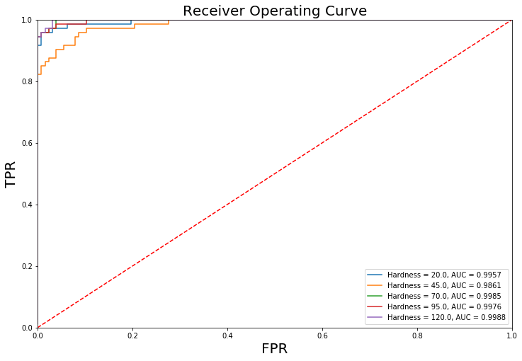

```python
range_hardness = hardness_best + np.linspace(-50,50,5)

plt.figure(figsize=(12,8))
plt.title(f"Receiver Operating Curve", size=20)
plt.ylabel('TPR', size=20)
plt.xlabel('FPR', size=20)
plt.xlim([0, 1])
plt.ylim([0, 1])

plt.plot([0, 1], [0, 1],'r--')
for i in range_hardness:
    auc, tpr, fpr, th = roc_curve(X_train_bal, Y_train_bal, X_test, Y_test, i)
    plt.plot(fpr, tpr,label = f"Hardness = {i}, AUC = {auc:0.4f}")

plt.legend(loc = 'lower right')
plt.show()
```

We observe the same trend as before- consistently high accuracy in the model fit across different hardness values, although the AUC for the optimal hardness is equal to 0.9985 when we trained our model on the unbalanced data and the balanced data.

When working with balanced data the out of sample accuracy increases from 0.955 to 0.98. This affirms soft-margin SVM's typically perform better with balanced data, as opposed to unbalanced data. This is because with unbalanced data, the optimisation problem becomes inaccurate, as it seeks to minimise the violation of constraints (failure in seperation) so it skews towards the class with less data points, leading to biased predictions.

## Summary

```python
df1 = pd.DataFrame(np.array([[0.872,0.872,0.816],[0.864,0.864,0.806]]),
                   columns = ["Linear", "Ridge", "Lasso-Huber"], index = ["Training data", "Test data"])
df2 = pd.DataFrame(np.array([[1,0.996,0.982],[1,0.975,0.955]]),
                   columns = ["kNN", "Random forests", "SVM"], index = ["Unbalanced Training data","Test data"])
df3 =  pd.DataFrame(np.array([[0.975],[0.98]]),
                   columns = ["SVM"], index = ["Balanced Training data", "Test data"])


from IPython.display import display_html
df1_ = df1.style.set_table_attributes("style='display:inline'").set_caption('Coefficient of determination for regression schemes')
df2_ = df2.style.set_table_attributes("style='display:inline'").set_caption('Accuracy for regression schemes')
df3_ = df3.style.set_table_attributes("style='display:inline'").set_caption('Accuracy for SVM')
display_html(df1_._repr_html_()+df2_._repr_html_()+df3_._repr_html_(), raw=True)
```

Coefficient of determination for regression schemes

|  | Linear | Ridge | Lasso-Huber |
| --- | --- | --- | --- |
| Training data | 0.872 | 0.872 | 0.816 |
| Test data | 0.864 | 0.864 | 0.806 |

Accuracy for regression schemes

|  | kNN | Random forests | SVM |
| --- | --- | --- | --- |
| Unbalanced Training data | 1 | 0.996 | 0.982 |
| Test data | 1 | 0.975 | 0.955 |

Accuracy for SVM

|  | SVM |
| --- | --- |
| Balanced Training data | 0.975 |
| Test data | 0.98 |